# Data 624 - HA Assignments

#### b

```r
brick_seas <- decompose(bricksq, type = "multiplicative")$seasonal
brick_seas
```

```
##          Qtr1     Qtr2     Qtr3     Qtr4
## 1956 0.907788 1.027191 1.061155 1.003866
## 1957 0.907788 1.027191 1.061155 1.003866
## 1958 0.907788 1.027191 1.061155 1.003866
## 1959 0.907788 1.027191 1.061155 1.003866
## 1960 0.907788 1.027191 1.061155 1.003866
## 1961 0.907788 1.027191 1.061155 1.003866
## 1962 0.907788 1.027191 1.061155 1.003866
## 1963 0.907788 1.027191 1.061155 1.003866
## 1964 0.907788 1.027191 1.061155 1.003866
## 1965 0.907788 1.027191 1.061155 1.003866
## 1966 0.907788 1.027191 1.061155 1.003866
## 1967 0.907788 1.027191 1.061155 1.003866
## 1968 0.907788 1.027191 1.061155 1.003866
## 1969 0.907788 1.027191 1.061155 1.003866
```

[output cut: 25 more lines]

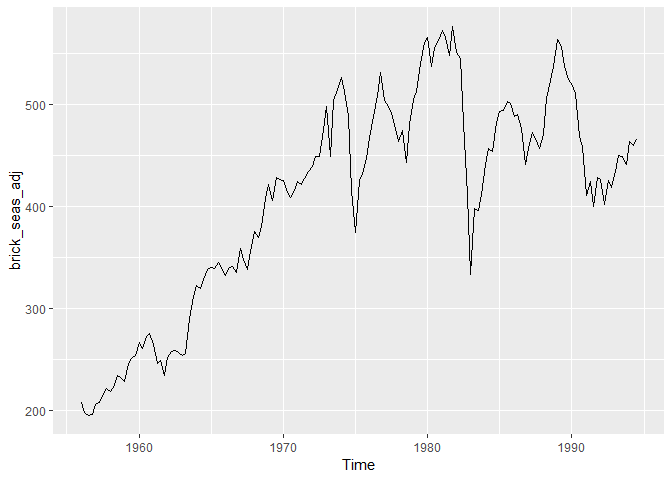

```r
brick_seas_adj = bricksq/brick_seas
autoplot(brick_seas_adj)
```

#### c

```r
brick_naive <- naive(brick_seas_adj, h = 12)
brick_naive
```

```
##         Point Forecast    Lo 80    Hi 80    Lo 95    Hi 95
## 1994 Q4       465.5304 438.0189 493.0419 423.4551 507.6056
## 1995 Q1       465.5304 426.6232 504.4375 406.0270 525.0337
## 1995 Q2       465.5304 417.8790 513.1817 392.6539 538.4068
## 1995 Q3       465.5304 410.5073 520.5534 381.3799 549.6808
## 1995 Q4       465.5304 404.0128 527.0480 371.4473 559.6134
## 1996 Q1       465.5304 398.1412 532.9195 362.4675 568.5932
## 1996 Q2       465.5304 392.7417 538.3190 354.2098 576.8509
## 1996 Q3       465.5304 387.7161 543.3447 346.5237 584.5371
## 1996 Q4       465.5304 382.9958 548.0649 339.3047 591.7560
## 1997 Q1       465.5304 378.5313 552.5294 332.4768 598.5839
## 1997 Q2       465.5304 374.2850 556.7757 325.9826 605.0781
## 1997 Q3       465.5304 370.2277 560.8330 319.7775 611.2832
```

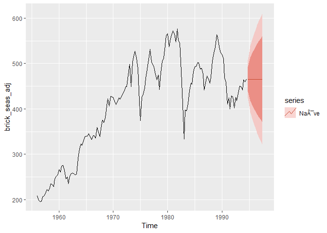

```r
autoplot(brick_seas_adj) + autolayer(brick_naive, series = "NaÃ¯ve", PI = TRUE)
```

#### d

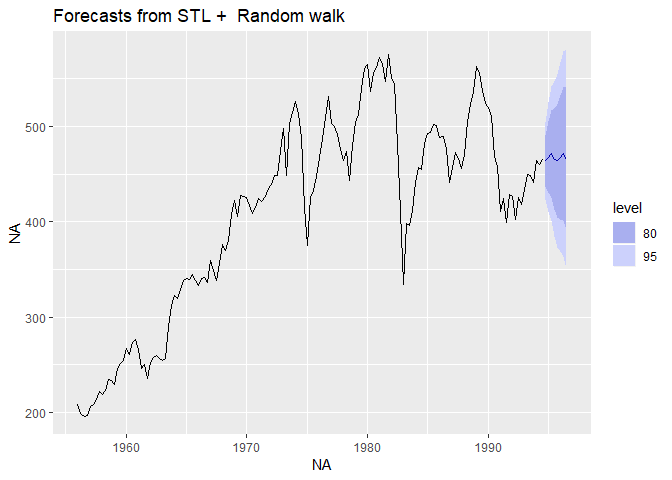

```r
fcast <- stlf(brick_seas_adj, method = "naive")
autoplot(fcast)
```

#### e

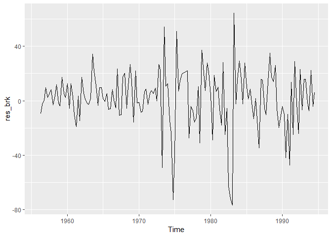

```r
res_brk <- residuals(brick_naive)
autoplot(res_brk)
```

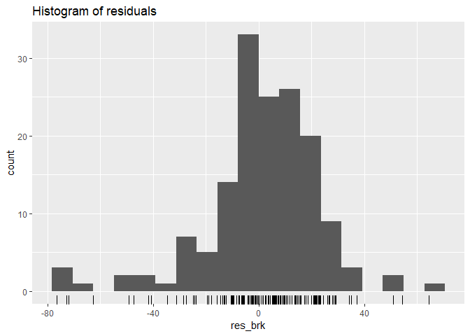

```r
gghistogram(res_brk) + ggtitle("Histogram of residuals")
```

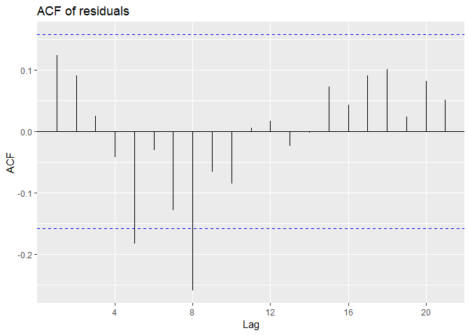

```r
ggAcf(res_brk) + ggtitle("ACF of residuals")
```

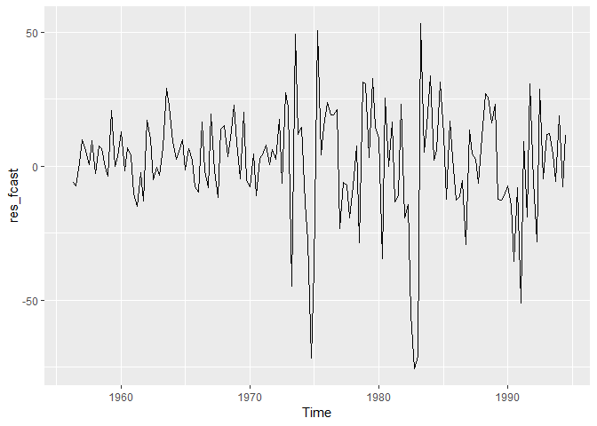

```r
res_fcast <- residuals(fcast)
autoplot(res_fcast)
```

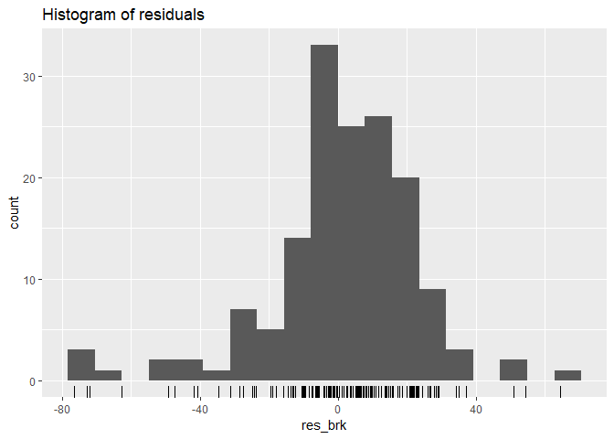

```r
gghistogram(res_brk) + ggtitle("Histogram of residuals")
```

They seem to increse as time increases, so no they do not look uncorrelated. Also a couple of the lags show significance, that may or may not be by chance.

#### f

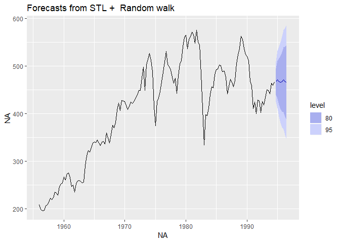

```r
brick_stl <- brick_seas_adj %>% stlf(t.window = 7, s.window = "periodic", method = "naive",
    robust = TRUE)
brick_stl %>% autoplot()
```

In this instance, it the residuals appear to behave similarly to a STL decompostion that is not robust.

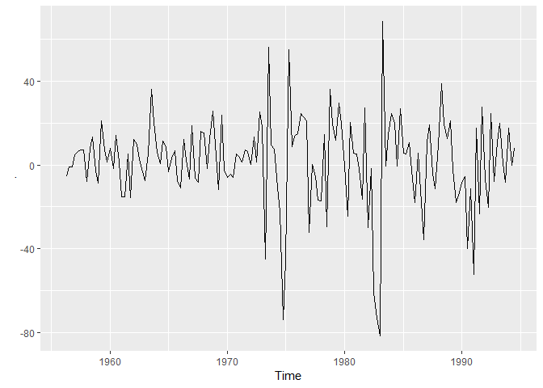

```r
res_brk2 <- brick_stl %>% residuals()
res_brk2 %>% autoplot()
```

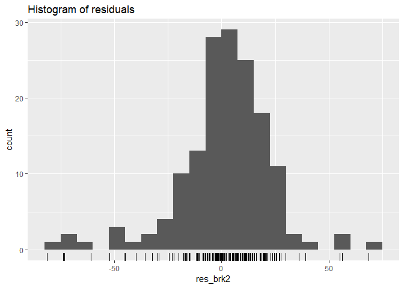

```r
gghistogram(res_brk2) + ggtitle("Histogram of residuals")
```

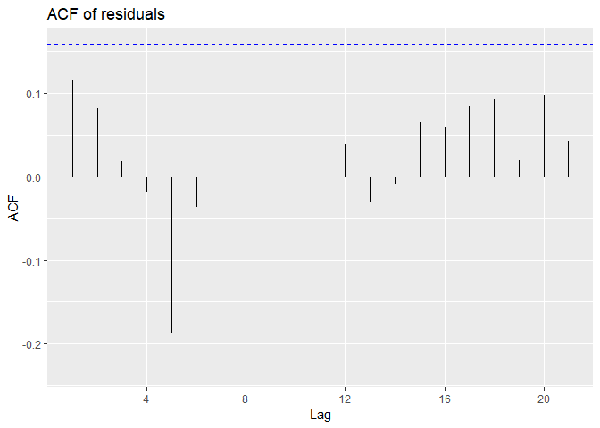

```r
ggAcf(res_brk2) + ggtitle("ACF of residuals")
```

#### g

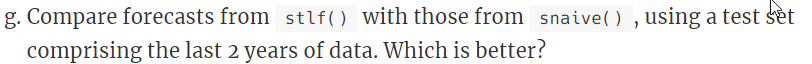

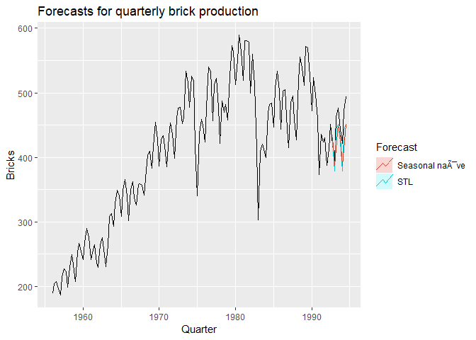

```r
train <- bricksq %>% window(1956, c(1992, 3))
test <- bricksq %>% window(c(1992, 4), c(1994, 4))
train_stlf <- train %>% stlf(method = "naive", h = 8)
train_snaiv <- train %>% snaive(h = 8)
autoplot(bricksq) + autolayer(train_stlf, series = "STL", PI = FALSE) + autolayer(train_snaiv,
    series = "Seasonal naÃ¯ve", PI = FALSE) + xlab("Quarter") + ylab("Bricks") +
    ggtitle("Forecasts for quarterly brick production") + guides(colour = guide_legend(title = "Forecast"))
```

From the graphs, it is hard to tell.

```r
accuracy(train_snaiv, test)
```

```
##                     ME     RMSE      MAE      MPE     MAPE      MASE
## Training set  6.174825 49.71281 36.41259 1.369661 8.903098 1.0000000
## Test set     27.500000 35.05353 30.00000 5.933607 6.528845 0.8238909
##                   ACF1 Theil's U
## Training set 0.8105927        NA
## Test set     0.2405423 0.9527794
```

```r
accuracy(train_stlf, test)
```

```
##                     ME     RMSE      MAE       MPE     MAPE      MASE
## Training set  1.457806 20.31551 14.65964 0.3594803 3.606373 0.4025982
## Test set     23.795651 27.73302 24.77223 5.2310577 5.463576 0.6803205
##                   ACF1 Theil's U
## Training set 0.2005515        NA
## Test set     0.2530477 0.7247275
```

From the accuracy fucnction, it appears that the STL decomposition performs better by yeilding less error in ME, RMSE, MAE, MPE, MAPE, and MASE.

### 3.1

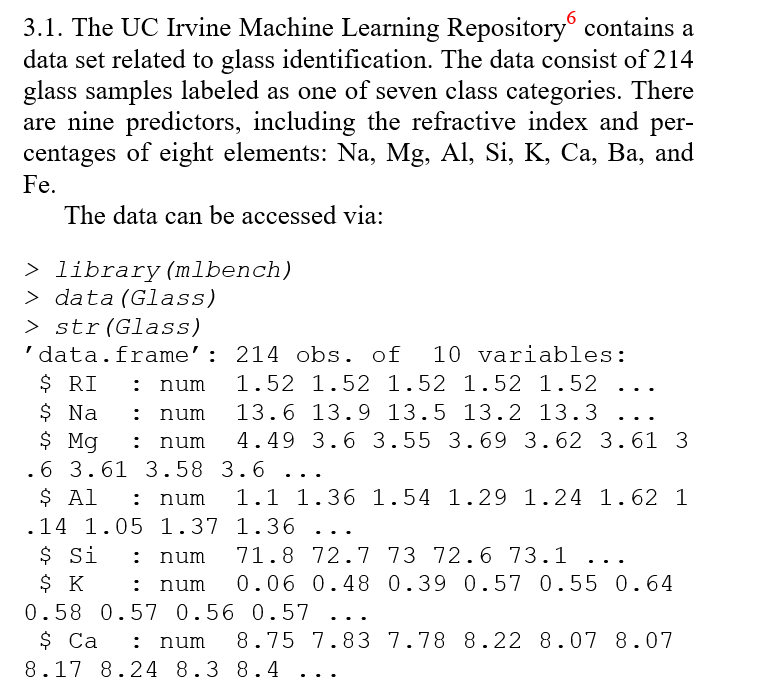

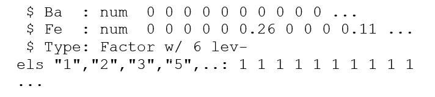

#### 3.1a

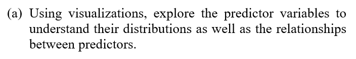

#### 3.1b

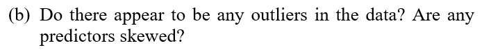

#### 3.1c

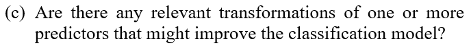

### 3.2

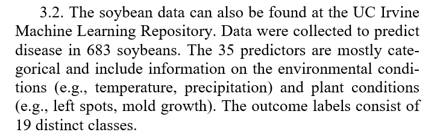

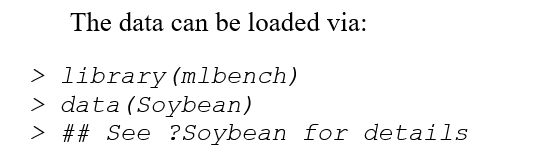

#### 3.2a

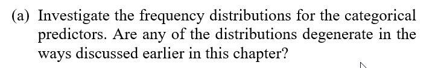

#### 3.2b

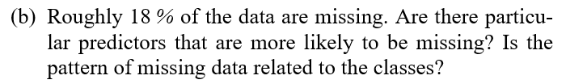

#### 3.2c

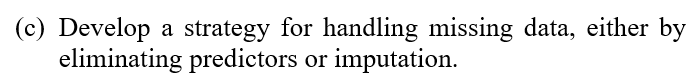